# Présentation

### Single

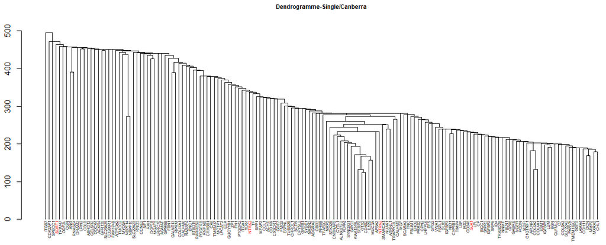

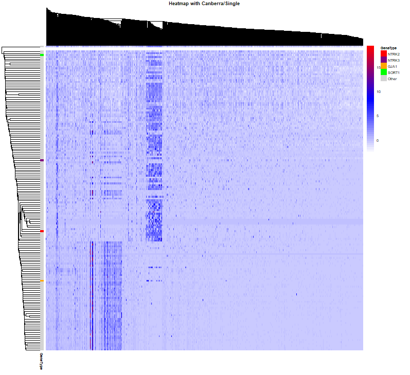

### Mcquitty

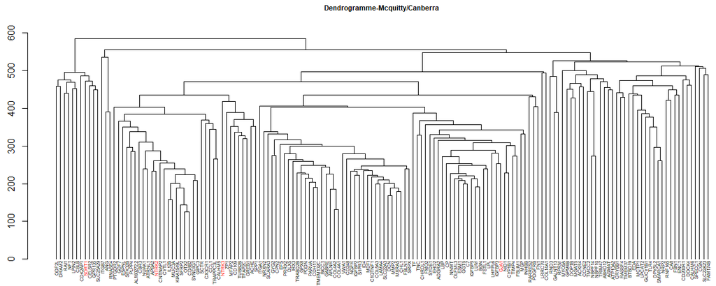

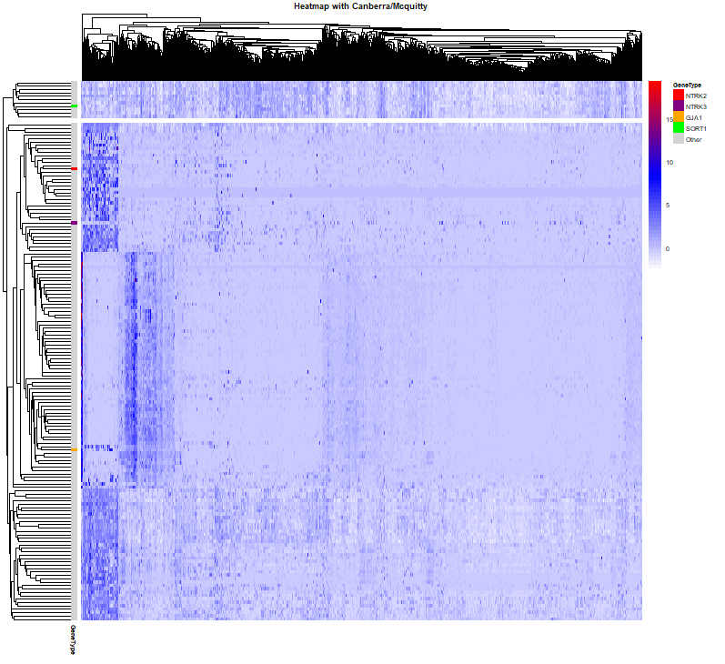

# Conclusion

## Résultats

### Euclidean

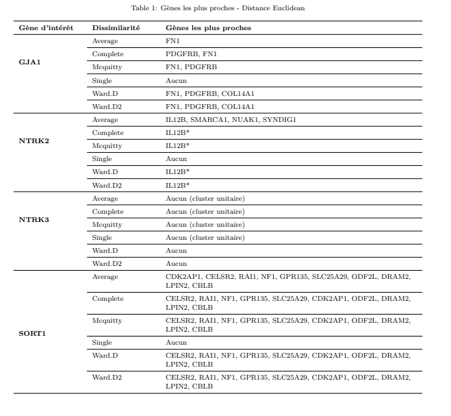

### Maximum

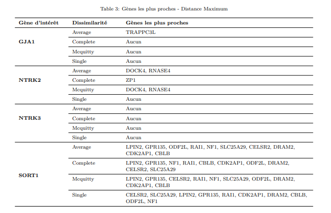

### Manhattan

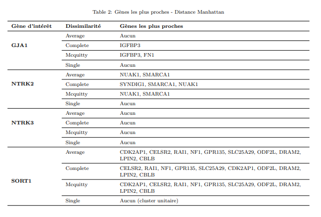

### Canberra

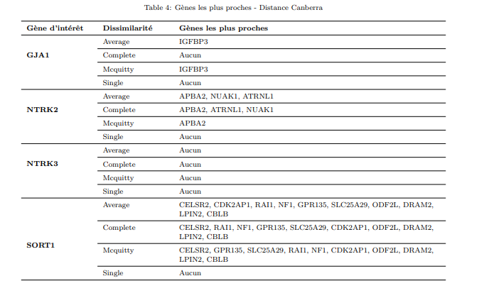

### Conclusion générale

#### Analyse de la qualité du clustering

Les scores de silhouettes présentés dans la partie Clustering montrent une qualité de clustering faible à modérée, avec des scores variant de 0.2 à 0.44 selon les distances/dissimilarités. La distance **Maximum** couplée aux dissimilarités Mcquitty et Average présente les meilleurs performances. Cette distance, sensible aux valeurs extrêmes semblent être adaptée à la structure des données, en la capturant en 2 ou 3 clusters. La distance **euclidienne** fournit des scores modérés et semble séparés en 3 ou 4 clusters aux profils particulièrement différents (voir heatmaps). La distance de **Manhanttan** offre des scores similaires à Euclidean mais est cependant moins discriminante (2 clusters majoritairement). Enfin, la distance de **Canberra** présente des scores de silhouette plus faibles, indiquant une capacité moindre à clusteriser les données.

#### Nombre de clusters

Le nombre de clusters varient entre **2** et **4,** avec une tendance à 2 ou 3 clusters pour les meilleurs performances. Le clustering hiérarchique semble donc avoir permis d’observer la structuration globale des données, sans pour autant parvenir à décrire des caractéristiques particulières. En effet, des clusters contenant seulement 1 gène sont observables pour plusieurs couples de distance/dissimilarité (ex : Euclidean/Mcquitty, Manhattan/Single).

Une **certaine structure** apparaît à plusieurs reprises dans nos résultats : la séparation d’un cluster d’une dizaine de gènes (dont SORT1) avec un ou plusieurs gros clusters contenant le reste des données, compliquant ainsi l’interprétation.

#### Synthèse des résultats par gène d’intérêt

- GJA1

Les gènes associés varient selon les distances. Euclidean identifie **FN1**, **PDGFRB**, et **COL14A1** (surtout avec Ward.D/Ward.D2), Manhattan et Canberra mettent en avant **IGFBP3**, tandis que Maximum pointe **TRAPPC3L**. Il est intéressant de remarquer que le gène **FN1** est particulièrement mis en avant (Distance euclidienne et de Manhattan).

Il est intéressant de noter que **GJA1** (avec **FN1**) montre souvent une expression plus forte pour des petits groupes d’individus, démarquant avec les gènes au alentour (ex : heatmap Euclidean/Ward.D2).

- NTRK2

Euclidean met en avant **IL12B** (surtout avec Complete/Mcquitty/Ward), Manhattan favorise **NUAK1/SMARCA1**, Maximum identifie **DOCK4**/**RNASE4**, et Canberra pointe **APBA2**.

Les observations des heatmaps ne montrent généralement pas de comportements caractéristiques (à la différence de **GJA1**), suggérant que **NTRK2** posséderait un comportement relativement moyen.

- NTRK3

**NTRK3** présente un comportement particulier, souvent classé dans un cluster individuel ou bien présentant des caractéristiques différentes des autres gènes (voir heatmaps). Son profil distinct des autres gènes n’a pas permis d’établir d’association.

- SORT1

**SORT1** présente une cohérence avec **CELSR2**, **RAI1**, **NF1**, **GPR135**, **SLC25A29**, **CDK2AP1**, **ODF2L**, **DRAM2**, **LPIN2**, **CBLB** à travers toutes les distances. Ce comportement est observable autant dans les dendogrammes (cluster entier) que dans les heatmaps.

### GJA1

Gènes Associés :

- **FN1** (Fibronectin 1) : Protéine de la matrice extracellulaire (MEC) impliquée notamment dans l’adhésion et la migration cellulaire (embryogénèse, coagulation,…).

*Lien Potentiel* : GJA1 et FN1 pourraient être liés via leur rôle dans le microenvironnement tumoral, où les jonctions gap (GJA1) et la MEC (FN1) influencent la survie et l’invasion des cellules cancéreuses.

- **PDGFRB** (Platelet-Derived Growth Factor Receptor Beta) : Récepteur tyrosine kinase impliqué dans la croissance, la prolifération et la survie cellulaire. Pour le myélome, il joue un rôle important dans l’angiogénèse, la prolifération et la dissémination. [*Bilalis et al., « Increased Expression of Platelet Derived Growth Factor Receptor β on Trephine Biopsies Correlates with Advanced Myeloma »*.]

*Lien Potentiel* : GJA1 pourrait interagir avec PDGFRB dans des voies de signalisation favorisant la prolifération et la survie des cellules tumorales.

- **COL14A1** (Collagen Type XIV Alpha 1) : Composant de la MEC, impliqué dans la structure des tissus conjonctifs (fibrillogenèse).

*Lien Potentiel* : Comme FN1, COL14A1 pourrait être lié à GJA1 via des interactions avec la MEC, influençant le microenvironnement tumoral.

- **IGFBP3** (Insulin-Like Growth Factor Binding Protein 3) : Régule la disponibilité de l’IGF, influençant la prolifération et l’apoptose. Dans le myélome, le système IGF (dont fait parti IGFBP3) contribue à la survie et la prolifération des cellules cancéreuses ainsi qu’à l’angiogénèse et l’ostéolyse. [*Bieghs et al., « The insulin-like growth factor system in multiple myeloma »*].

*Lien Potentiel* : GJA1 et IGFBP3 pourraient interagir dans la régulation de l’apoptose ou de la prolifération cellulaire.

- **TRAPPC3L** (trafficking protein particle complex subunit 3L) : Peu étudié, mais lié au trafic vésiculaire intracellulaire (appareil de Golgi).

### NTRK2

Gènes Associés :

- **IL12B** (Interleukin 12B) : Cytokine impliquée dans l’immunité (lymphocyte T). Observée dans le cadre de la Sclérose en plaques notamment en diminuant l’inflammation neuronale.
- **SMARCA1** (SNF2 related chromatin remodeling ATPase 1) : Impliqué dans le remodelage de la chromatine (transcription). Contribue également dans l’inihibtion de la croissance cellulaire et l’apoptose des cellules cancéreuses.
- **NUAK1** (NUAK Family Kinase 1) : Kinase impliquée dans la régulation de l’adhésion cellulaire et de la sénescence cellulaire (arrêt division cellulaire).

  *Lien Potentiel* : NTRK2 et NUAK1 pourraient partager des voies de signalisation communes.
- **SYNDIG1** (Synapse Differentiation Inducing 1) : Protéine transmembranaire exprimée dans le système nerveux. Impliquée dans la formation des synapses, mais peu étudiée dans le cadre du cancer.
- **DOCK4** (Dedicator of Cytokinesis 4) : Impliqué dans la migration cellulaire et la régulation des jonctions adhérentes, entre autres. *Lien potentiel* : Interaction connue entre NTRK1 et DOCK4.
- **RNASE4** (Ribonuclease A Family Member 4) : Métabolisme de l’ARN, rôle dans la prolifération et l’angiogenèse tumorale ainsi que dans l’activation de récepteur tyrosine kinase dans le cadre du cancer de la prostate.
- **ZP1** (Zona Pellucida Glycoprotein 1) : Matrice extracellulaire impliquée dans la reproduction (régulation de la liaison avec les spermatozoïdes).
- **APBA2** (Amyloid Beta Precursor Protein Binding Family A Member 2) : Impliquée dans le trafic neuronal (protéine adaptatrice neuronale).

  *Lien potentiel* : Interaction possible dans des contextes où NTRK2 joue un rôle neuronal.
- **ATRNL1** (Attractin Like 1) : Rôle peu clair dans le cancer.

### SORT1

Gènes Associés :

- **CELSR2** (Cadherin EGF LAG Seven-Pass G-Type Receptor 2) : Récepteur impliqué dans l’adhésion cellulaire et des interactions ligand-récepteur.
- **RAI1** (Retinoic Acid Induced 1) : Régulation transcriptionnelle particulièrement dans les neurones.
- **NF1** (Neurofibromin 1) : Régule la voie MAPK/ERK (négativement). Impliqué dans la croissance et la prolifération cellulaires notamment.
- **GPR135** (G Protein-Coupled Receptor 135) : Récepteur orphelin couplé aux protéines G (transduction du signal).
- **SLC25A29** (Solute Carrier Family 25 Member 29) : Transport d’acides aminés jusqu’aux mitochondries (synthèse de protéines mitochondrial).
- **CDK2AP1** (Cyclin Dependent Kinase 2 Associated Protein 1) : Régulation (négative) du cycle cellulaire. Inhibe l’activité de CDK2 (rôle dans initialisation synthèse d’ADN).
- **ODF2L** (Outer Dense Fiber of Sperm Tails 2 Like) : Impliqué dans l’inhibition de la ciliogenèse (formation des cils, rôle dans communication cellulaire et contrôle de la division notamment).
- **DRAM2** (DNA Damage Regulated Autophagy Modulator 2) : Impliqué dans l’autophagie et l’apoptose.
- **LPIN2** (Lipin 2) : Métabolisme des lipides, rôle potentiel dans l’inflammation.
- **CBLB** (Cbl Proto-Oncogene B) : Impliqué dans la réponse immunitaire en limitant les récepteurs aux cellules T et B.

Lien Potentiel : Ce groupe de gènes est très cohérent à travers les distances et dissimilarités, suggérant une co-régulation avec SORT1. Plusieurs gènes (NF1, CDK2AP1, DRAM2,ODF2L) sont liés à des processus oncogéniques (cycle cellulaire, apoptose, signalisation). Cela pourrait indiquer que SORT1 est impliqué dans un réseau régulant la progression tumorale dans le myélome multiple.